# Experiments with groups of stations: julian date quantiles

FBK

9 januar 2017

```
## [1] "q25"
```

```
##    25%
## 156.25
```

```
## [1] "q50"
```

```
## [1] 176
```

```
## [1] "q75"
```

```
##     75%
## 247.875
```

## QS

[1] “QS” [1] 2 [1] 1 2 5 6 7 8 9 10 11 15 20 21 22 23 24 25 27 [18] 30 35 36 37 38 39 40 43 44 45 47 49 50 51 53 54 55 [35] 56 57 59 64 77 158 166 167 168 171 172 173 174 175 176 180 185 [52] 186 187 189 190 210 211 213 228 229 244 253 254 255 257 258 259 260 [69] 263 287 288 289 290 295 298 304 306 [1] “done printint”

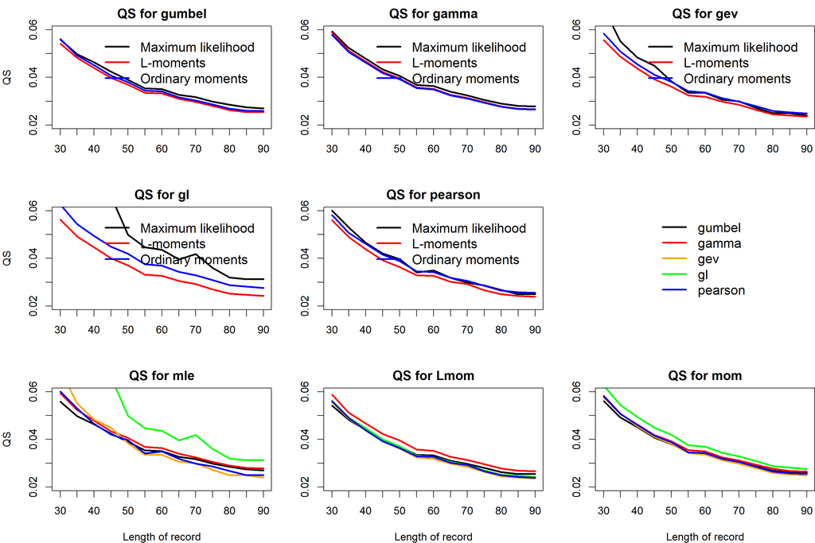

[1] “QS” [1] 2 [1] 4 16 17 26 42 46 58 72 79 100 115 116 117 119 121 149 150 [18] 152 153 154 155 159 160 161 162 178 181 188 191 193 195 196 198 202 [35] 208 212 214 224 231 232 233 234 235 236 237 238 239 240 241 242 243 [52] 245 246 247 248 249 250 251 252 256 261 262 264 265 266 272 284 285 [69] 292 293 294 297 301 303 [1] “done printint”

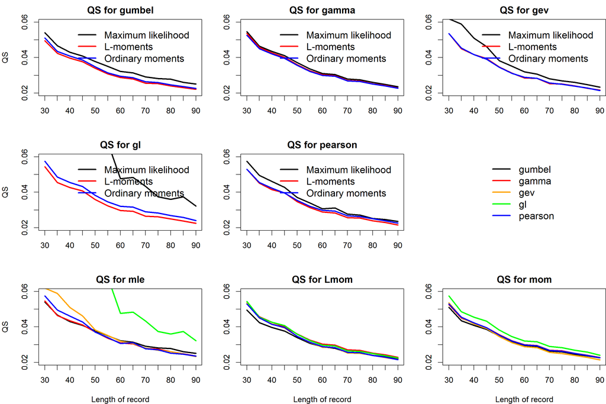

[1] “QS” [1] 2 [1] 3 13 14 18 19 33 34 41 48 52 60 61 65 67 68 69 70 [18] 89 90 99 104 105 106 111 112 113 118 120 122 123 124 125 131 132 [35] 134 135 143 144 151 156 157 163 164 165 169 170 177 179 183 192 197 [52] 199 200 203 205 206 207 209 215 218 219 222 223 230 271 273 274 280 [69] 281 286 299 300 [1] “done printint”

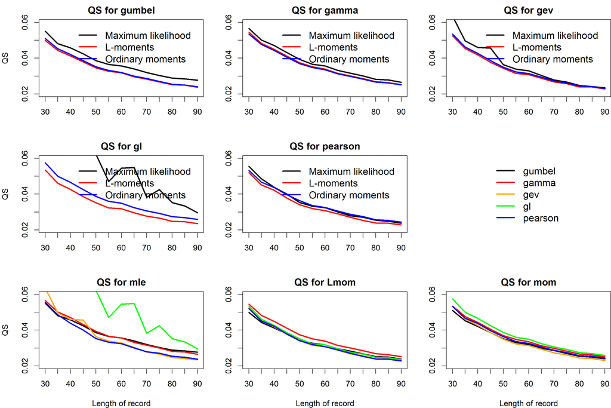

[1] “QS” [1] 2 [1] 28 29 31 32 62 63 66 71 73 74 75 76 78 80 81 82 83 [18] 84 85 86 87 88 91 92 93 94 95 96 97 98 101 102 103 107 [35] 108 109 110 126 127 128 129 130 133 136 137 138 139 140 141 142 145 [52] 146 147 148 182 184 201 204 216 220 225 226 227 267 268 269 270 275 [69] 276 277 278 279 282 283 291 302 305 [1] “done printint”

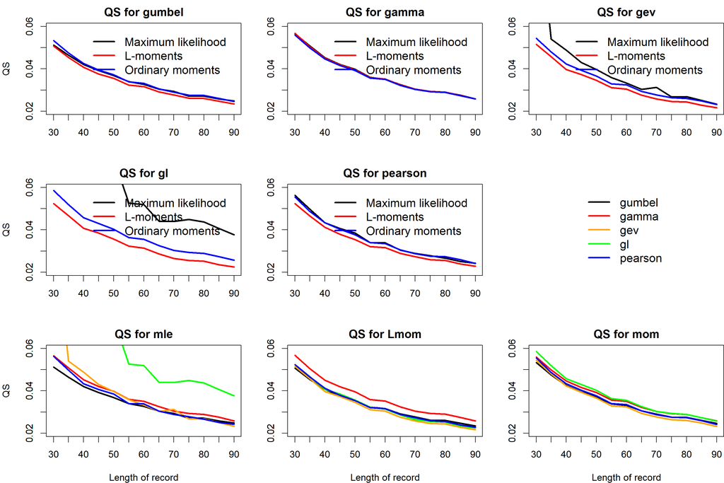

## BS

[1] “BS” [1] 2 [1] 1 2 5 6 7 8 9 10 11 15 20 21 22 23 24 25 27 [18] 30 35 36 37 38 39 40 43 44 45 47 49 50 51 53 54 55 [35] 56 57 59 64 77 158 166 167 168 171 172 173 174 175 176 180 185 [52] 186 187 189 190 210 211 213 228 229 244 253 254 255 257 258 259 260 [69] 263 287 288 289 290 295 298 304 306 [1] “done printint”

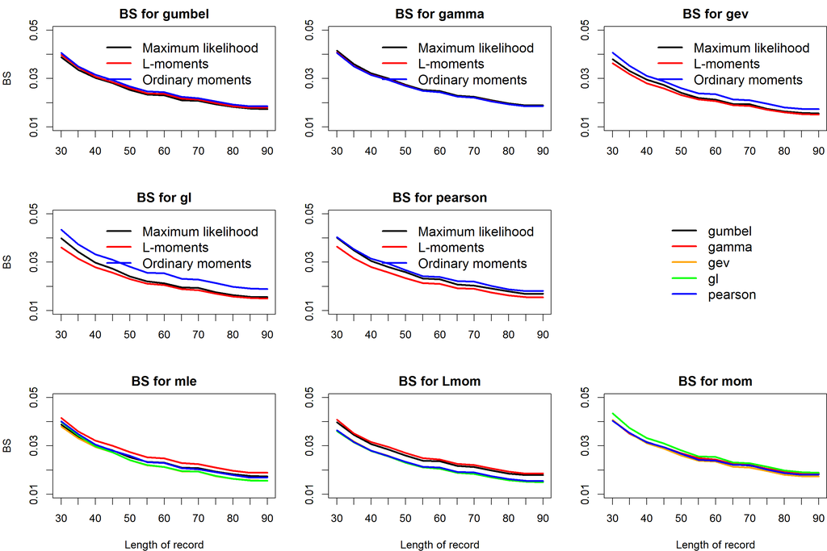

[1] “BS” [1] 2 [1] 4 16 17 26 42 46 58 72 79 100 115 116 117 119 121 149 150 [18] 152 153 154 155 159 160 161 162 178 181 188 191 193 195 196 198 202 [35] 208 212 214 224 231 232 233 234 235 236 237 238 239 240 241 242 243 [52] 245 246 247 248 249 250 251 252 256 261 262 264 265 266 272 284 285 [69] 292 293 294 297 301 303 [1] “done printint”

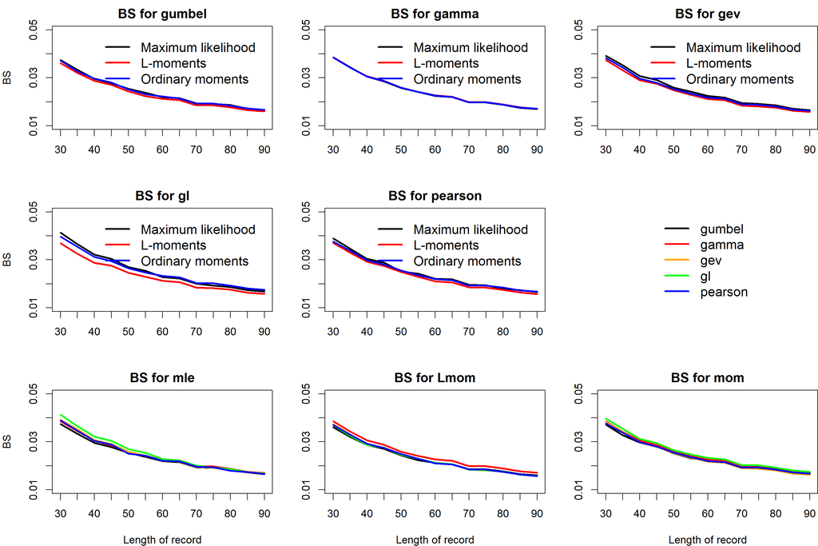

[1] “BS” [1] 2 [1] 3 13 14 18 19 33 34 41 48 52 60 61 65 67 68 69 70 [18] 89 90 99 104 105 106 111 112 113 118 120 122 123 124 125 131 132 [35] 134 135 143 144 151 156 157 163 164 165 169 170 177 179 183 192 197 [52] 199 200 203 205 206 207 209 215 218 219 222 223 230 271 273 274 280 [69] 281 286 299 300 [1] “done printint”

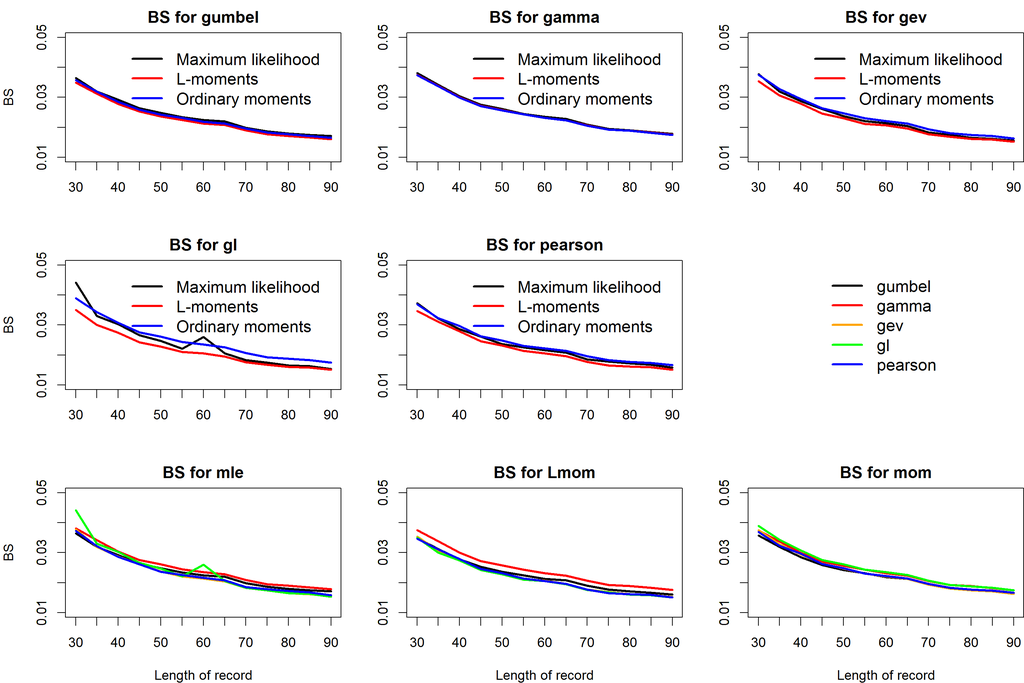

[1] “BS” [1] 2 [1] 28 29 31 32 62 63 66 71 73 74 75 76 78 80 81 82 83 [18] 84 85 86 87 88 91 92 93 94 95 96 97 98 101 102 103 107 [35] 108 109 110 126 127 128 129 130 133 136 137 138 139 140 141 142 145 [52] 146 147 148 182 184 201 204 216 220 225 226 227 267 268 269 270 275 [69] 276 277 278 279 282 283 291 302 305 [1] “done printint”

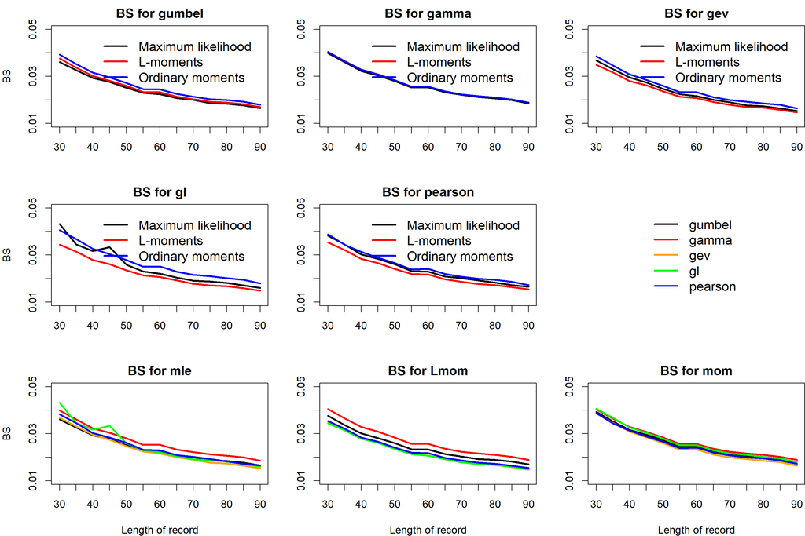

## Return levels

#### RL 10y

[1] “r.levels” [1] 10 [1] 1 2 5 6 7 8 9 10 11 15 20 21 22 23 24 25 27 [18] 30 35 36 37 38 39 40 43 44 45 47 49 50 51 53 54 55 [35] 56 57 59 64 77 158 166 167 168 171 172 173 174 175 176 180 185 [52] 186 187 189 190 210 211 213 228 229 244 253 254 255 257 258 259 260 [69] 263 287 288 289 290 295 298 304 306 [1] “done printint”

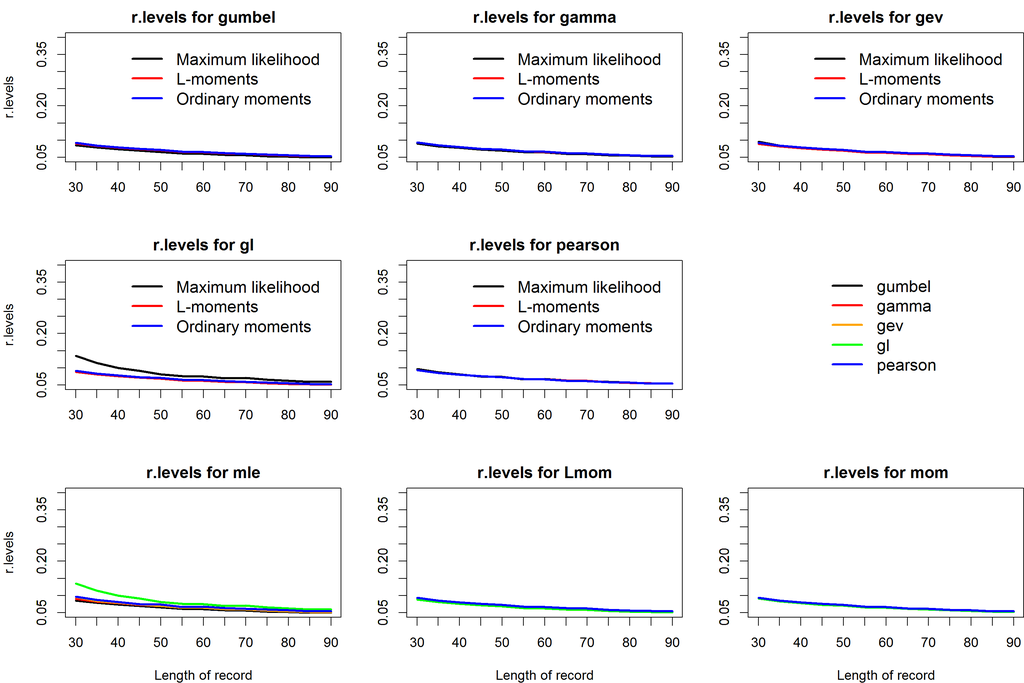

[1] “r.levels” [1] 10 [1] 4 16 17 26 42 46 58 72 79 100 115 116 117 119 121 149 150 [18] 152 153 154 155 159 160 161 162 178 181 188 191 193 195 196 198 202 [35] 208 212 214 224 231 232 233 234 235 236 237 238 239 240 241 242 243 [52] 245 246 247 248 249 250 251 252 256 261 262 264 265 266 272 284 285 [69] 292 293 294 297 301 303 [1] “done printint”

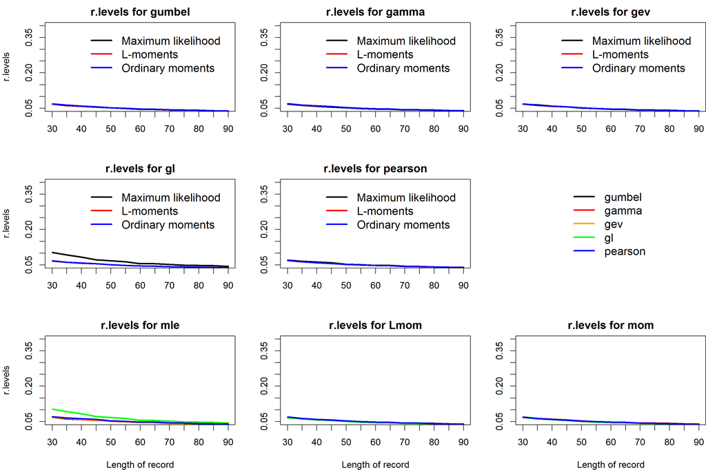

[1] “r.levels” [1] 10 [1] 3 13 14 18 19 33 34 41 48 52 60 61 65 67 68 69 70 [18] 89 90 99 104 105 106 111 112 113 118 120 122 123 124 125 131 132 [35] 134 135 143 144 151 156 157 163 164 165 169 170 177 179 183 192 197 [52] 199 200 203 205 206 207 209 215 218 219 222 223 230 271 273 274 280 [69] 281 286 299 300 [1] “done printint”

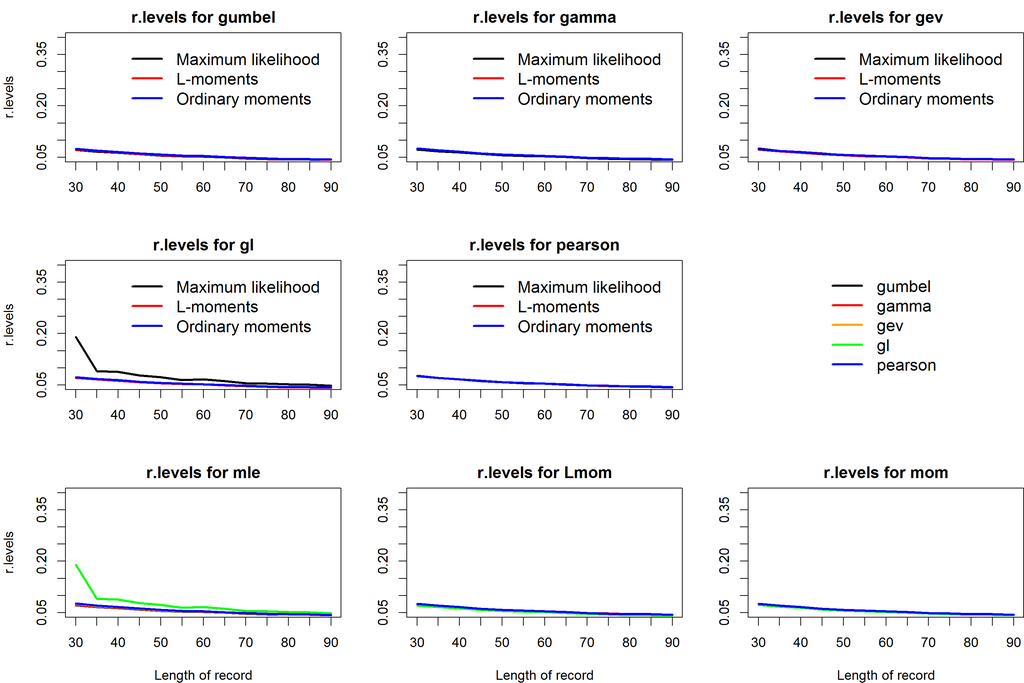

[1] “r.levels” [1] 10 [1] 28 29 31 32 62 63 66 71 73 74 75 76 78 80 81 82 83 [18] 84 85 86 87 88 91 92 93 94 95 96 97 98 101 102 103 107 [35] 108 109 110 126 127 128 129 130 133 136 137 138 139 140 141 142 145 [52] 146 147 148 182 184 201 204 216 220 225 226 227 267 268 269 270 275 [69] 276 277 278 279 282 283 291 302 305 [1] “done printint”

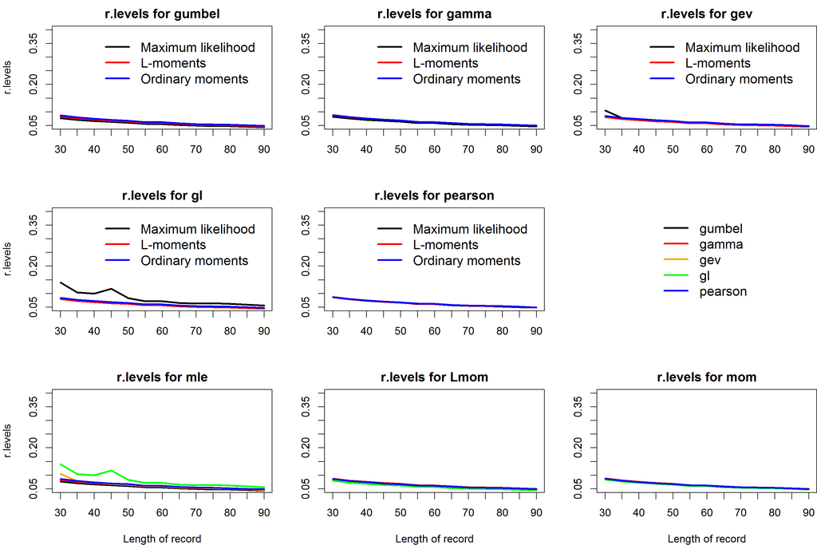

#### RL 100y

[1] “r.levels” [1] 100 [1] 1 2 5 6 7 8 9 10 11 15 20 21 22 23 24 25 27 [18] 30 35 36 37 38 39 40 43 44 45 47 49 50 51 53 54 55 [35] 56 57 59 64 77 158 166 167 168 171 172 173 174 175 176 180 185 [52] 186 187 189 190 210 211 213 228 229 244 253 254 255 257 258 259 260 [69] 263 287 288 289 290 295 298 304 306 [1] “done printint”

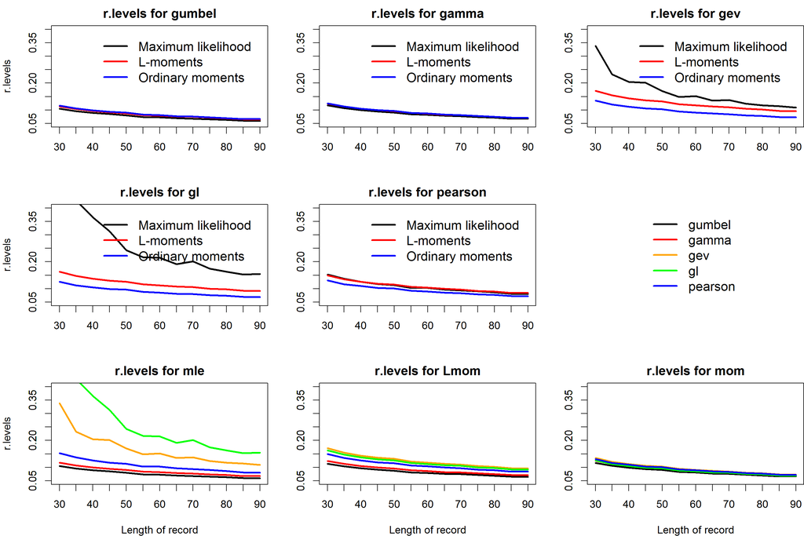

[1] “r.levels” [1] 100 [1] 4 16 17 26 42 46 58 72 79 100 115 116 117 119 121 149 150 [18] 152 153 154 155 159 160 161 162 178 181 188 191 193 195 196 198 202 [35] 208 212 214 224 231 232 233 234 235 236 237 238 239 240 241 242 243 [52] 245 246 247 248 249 250 251 252 256 261 262 264 265 266 272 284 285 [69] 292 293 294 297 301 303 [1] “done printint”

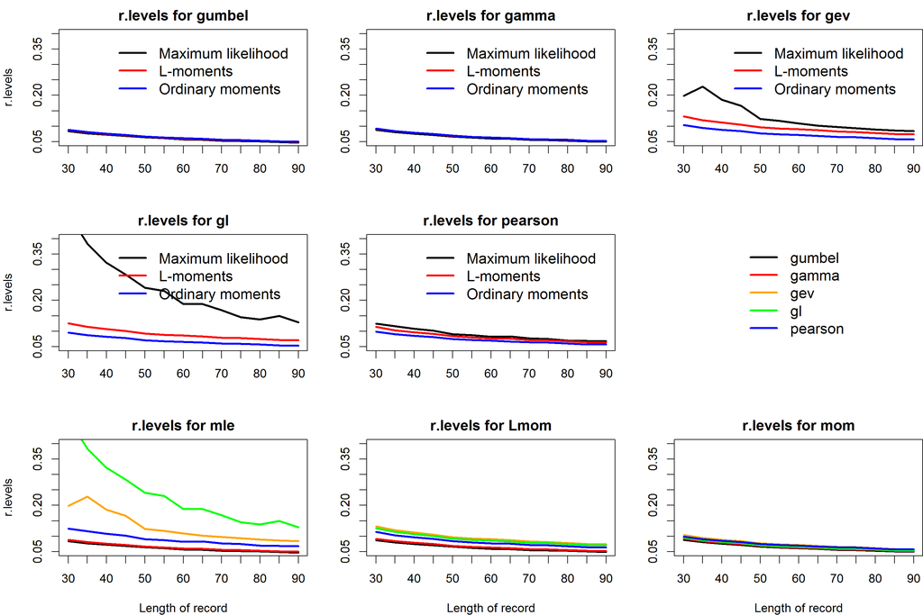

[1] “r.levels” [1] 100 [1] 3 13 14 18 19 33 34 41 48 52 60 61 65 67 68 69 70 [18] 89 90 99 104 105 106 111 112 113 118 120 122 123 124 125 131 132 [35] 134 135 143 144 151 156 157 163 164 165 169 170 177 179 183 192 197 [52] 199 200 203 205 206 207 209 215 218 219 222 223 230 271 273 274 280 [69] 281 286 299 300 [1] “done printint”

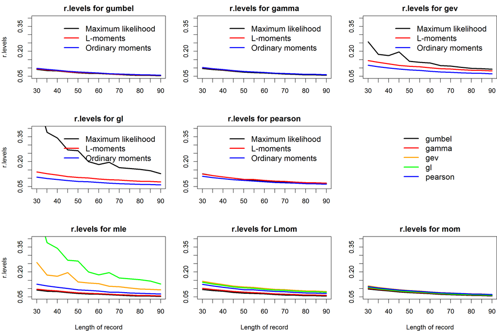

[1] “r.levels” [1] 100 [1] 28 29 31 32 62 63 66 71 73 74 75 76 78 80 81 82 83 [18] 84 85 86 87 88 91 92 93 94 95 96 97 98 101 102 103 107 [35] 108 109 110 126 127 128 129 130 133 136 137 138 139 140 141 142 145 [52] 146 147 148 182 184 201 204 216 220 225 226 227 267 268 269 270 275 [69] 276 277 278 279 282 283 291 302 305 [1] “done printint”

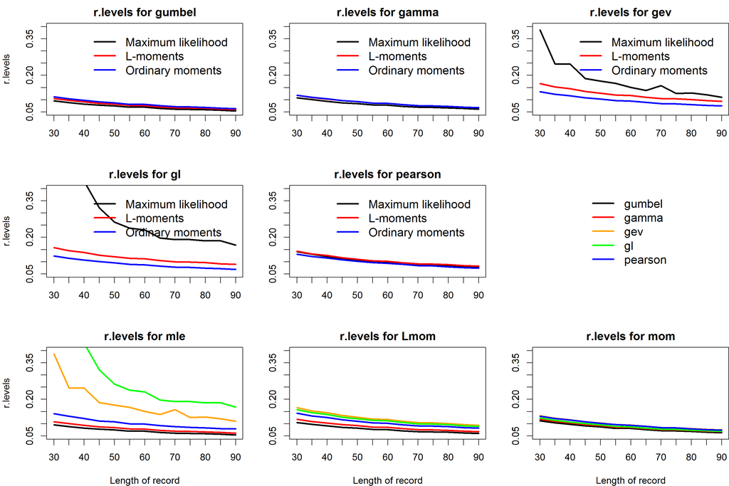

#### RL 200y

[1] “r.levels” [1] 200 [1] 1 2 5 6 7 8 9 10 11 15 20 21 22 23 24 25 27 [18] 30 35 36 37 38 39 40 43 44 45 47 49 50 51 53 54 55 [35] 56 57 59 64 77 158 166 167 168 171 172 173 174 175 176 180 185 [52] 186 187 189 190 210 211 213 228 229 244 253 254 255 257 258 259 260 [69] 263 287 288 289 290 295 298 304 306 [1] “done printint”

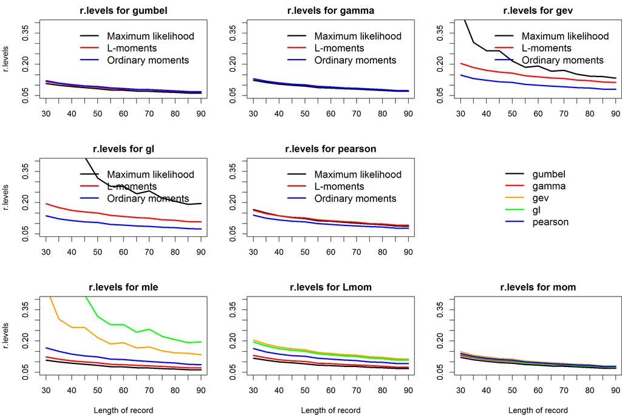

[1] “r.levels” [1] 200 [1] 4 16 17 26 42 46 58 72 79 100 115 116 117 119 121 149 150 [18] 152 153 154 155 159 160 161 162 178 181 188 191 193 195 196 198 202 [35] 208 212 214 224 231 232 233 234 235 236 237 238 239 240 241 242 243 [52] 245 246 247 248 249 250 251 252 256 261 262 264 265 266 272 284 285 [69] 292 293 294 297 301 303 [1] “done printint”

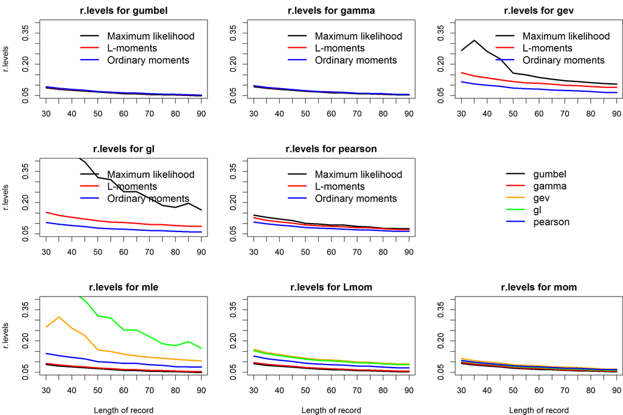

[1] “r.levels” [1] 200 [1] 3 13 14 18 19 33 34 41 48 52 60 61 65 67 68 69 70 [18] 89 90 99 104 105 106 111 112 113 118 120 122 123 124 125 131 132 [35] 134 135 143 144 151 156 157 163 164 165 169 170 177 179 183 192 197 [52] 199 200 203 205 206 207 209 215 218 219 222 223 230 271 273 274 280 [69] 281 286 299 300 [1] “done printint”

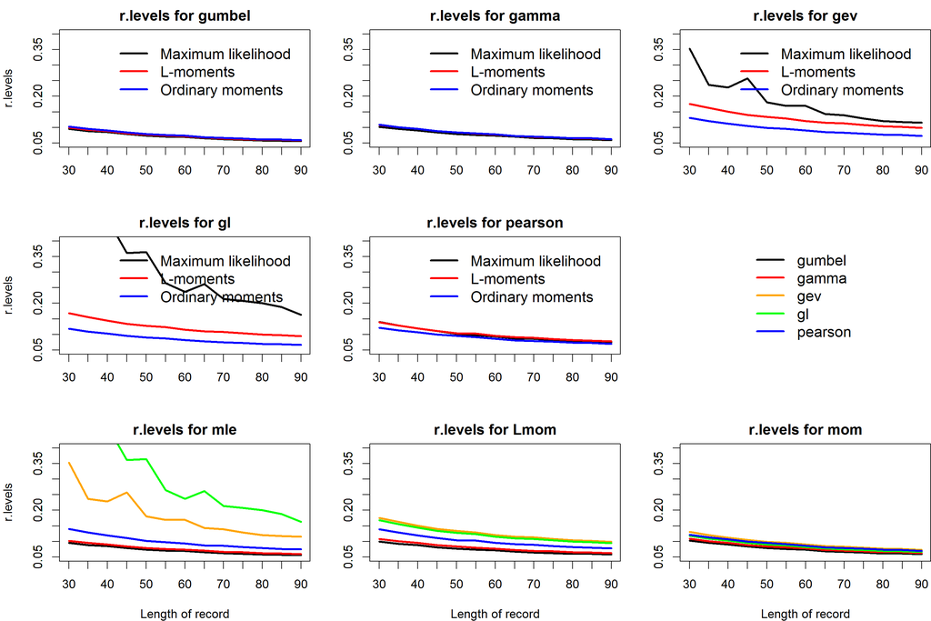

[1] “r.levels” [1] 200 [1] 28 29 31 32 62 63 66 71 73 74 75 76 78 80 81 82 83 [18] 84 85 86 87 88 91 92 93 94 95 96 97 98 101 102 103 107 [35] 108 109 110 126 127 128 129 130 133 136 137 138 139 140 141 142 145 [52] 146 147 148 182 184 201 204 216 220 225 226 227 267 268 269 270 275 [69] 276 277 278 279 282 283 291 302 305 [1] “done printint”

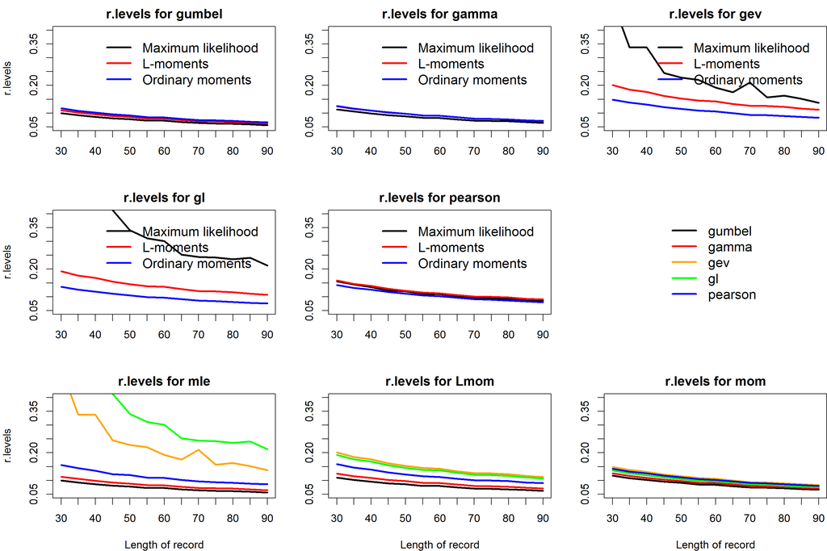

## KS

[1] 1 2 5 6 7 8 9 10 11 15 20 21 22 23 24 25 27 [18] 30 35 36 37 38 39 40 43 44 45 47 49 50 51 53 54 55 [35] 56 57 59 64 77 158 166 167 168 171 172 173 174 175 176 180 185 [52] 186 187 189 190 210 211 213 228 229 244 253 254 255 257 258 259 260 [69] 263 287 288 289 290 295 298 304 306 [1] “entered the plotting function” [1] 30 [1] 150

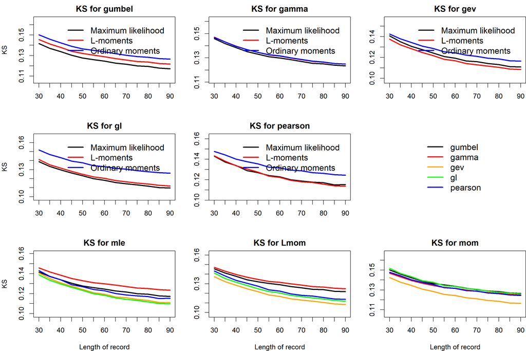

[1] 4 16 17 26 42 46 58 72 79 100 115 116 117 119 121 149 150 [18] 152 153 154 155 159 160 161 162 178 181 188 191 193 195 196 198 202 [35] 208 212 214 224 231 232 233 234 235 236 237 238 239 240 241 242 243 [52] 245 246 247 248 249 250 251 252 256 261 262 264 265 266 272 284 285 [69] 292 293 294 297 301 303 [1] “entered the plotting function” [1] 30 [1] 150

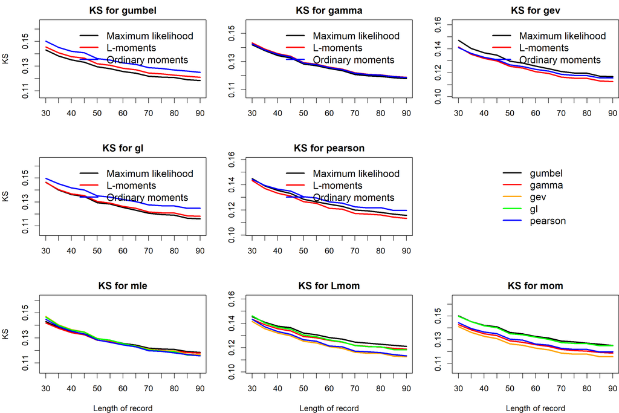

[1] 3 13 14 18 19 33 34 41 48 52 60 61 65 67 68 69 70 [18] 89 90 99 104 105 106 111 112 113 118 120 122 123 124 125 131 132 [35] 134 135 143 144 151 156 157 163 164 165 169 170 177 179 183 192 197 [52] 199 200 203 205 206 207 209 215 218 219 222 223 230 271 273 274 280 [69] 281 286 299 300 [1] “entered the plotting function” [1] 30 [1] 150

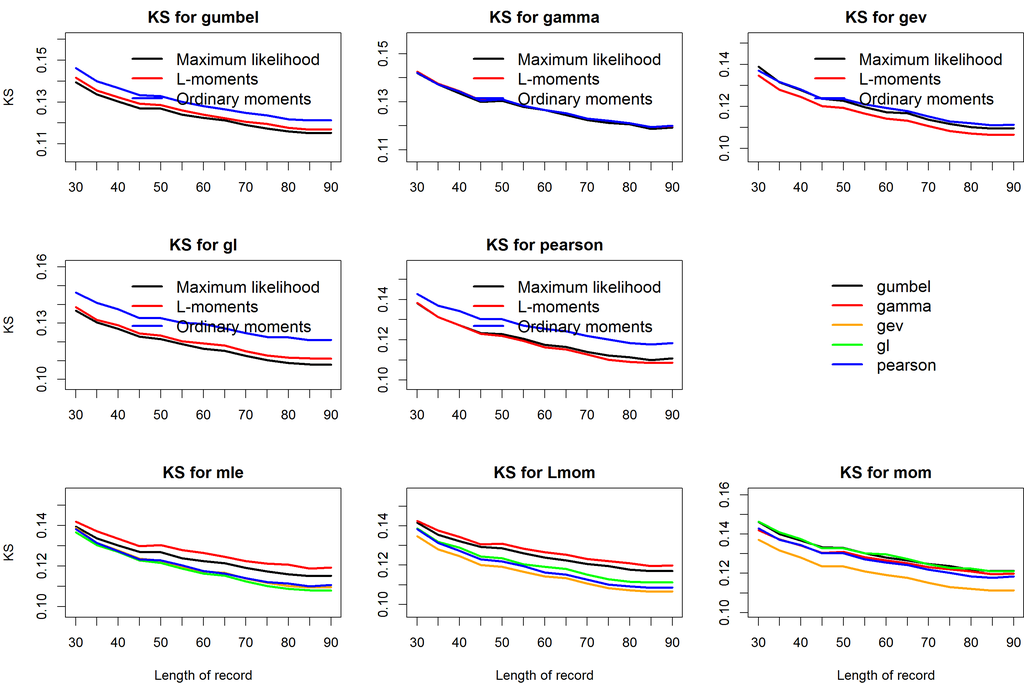

[1] 28 29 31 32 62 63 66 71 73 74 75 76 78 80 81 82 83 [18] 84 85 86 87 88 91 92 93 94 95 96 97 98 101 102 103 107 [35] 108 109 110 126 127 128 129 130 133 136 137 138 139 140 141 142 145 [52] 146 147 148 182 184 201 204 216 220 225 226 227 267 268 269 270 275 [69] 276 277 278 279 282 283 291 302 305 [1] “entered the plotting function” [1] 30 [1] 150

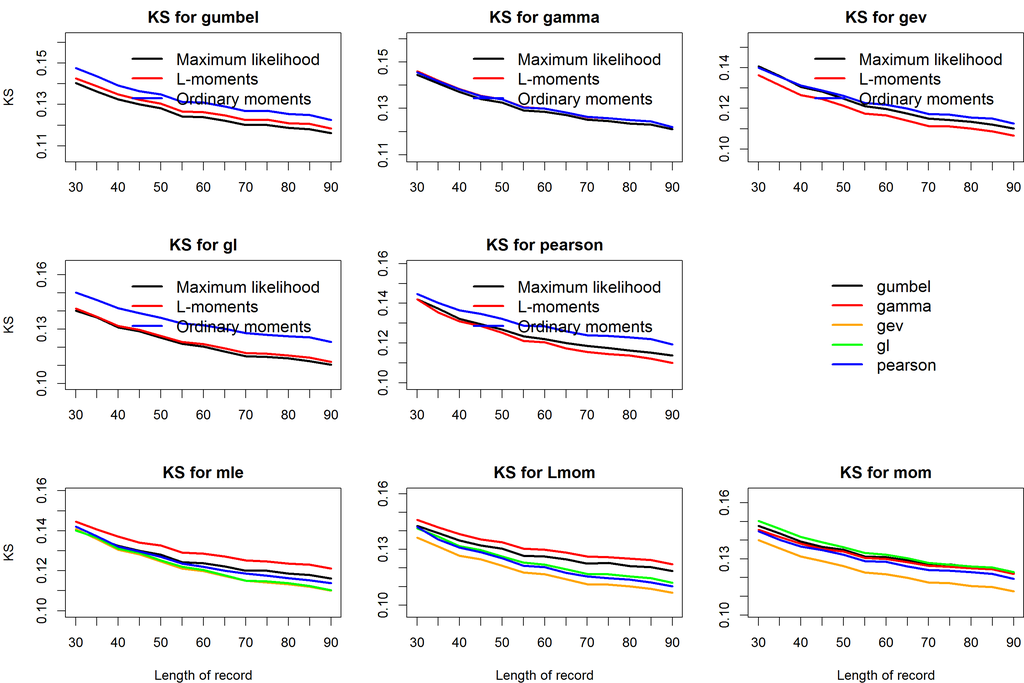

## AD

[1] 1 2 5 6 7 8 9 10 11 15 20 21 22 23 24 25 27 [18] 30 35 36 37 38 39 40 43 44 45 47 49 50 51 53 54 55 [35] 56 57 59 64 77 158 166 167 168 171 172 173 174 175 176 180 185 [52] 186 187 189 190 210 211 213 228 229 244 253 254 255 257 258 259 260 [69] 263 287 288 289 290 295 298 304 306 [1] “entered the plotting function” [1] 30 [1] 150

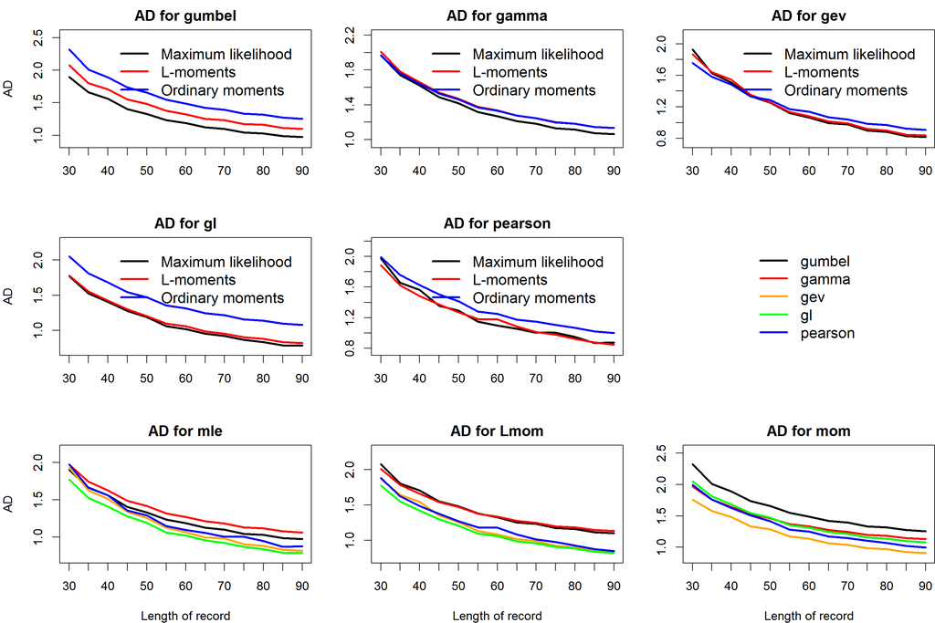

[1] 4 16 17 26 42 46 58 72 79 100 115 116 117 119 121 149 150 [18] 152 153 154 155 159 160 161 162 178 181 188 191 193 195 196 198 202 [35] 208 212 214 224 231 232 233 234 235 236 237 238 239 240 241 242 243 [52] 245 246 247 248 249 250 251 252 256 261 262 264 265 266 272 284 285 [69] 292 293 294 297 301 303 [1] “entered the plotting function” [1] 30 [1] 150

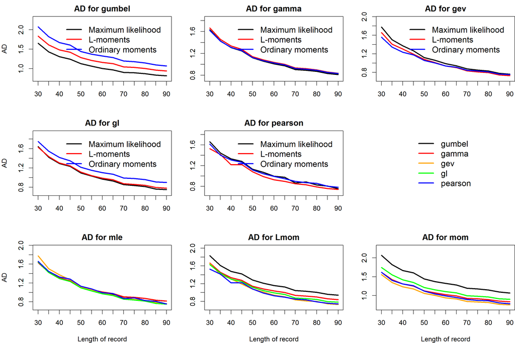

[1] 3 13 14 18 19 33 34 41 48 52 60 61 65 67 68 69 70 [18] 89 90 99 104 105 106 111 112 113 118 120 122 123 124 125 131 132 [35] 134 135 143 144 151 156 157 163 164 165 169 170 177 179 183 192 197 [52] 199 200 203 205 206 207 209 215 218 219 222 223 230 271 273 274 280 [69] 281 286 299 300 [1] “entered the plotting function” [1] 30 [1] 150

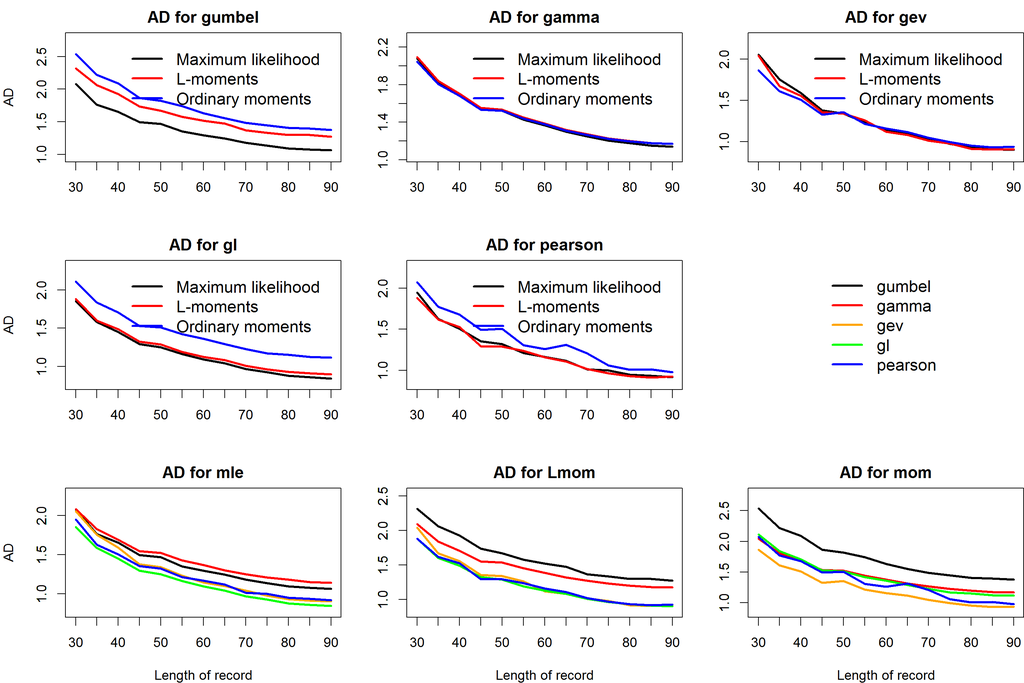

[1] 28 29 31 32 62 63 66 71 73 74 75 76 78 80 81 82 83 [18] 84 85 86 87 88 91 92 93 94 95 96 97 98 101 102 103 107 [35] 108 109 110 126 127 128 129 130 133 136 137 138 139 140 141 142 145 [52] 146 147 148 182 184 201 204 216 220 225 226 227 267 268 269 270 275 [69] 276 277 278 279 282 283 291 302 305 [1] “entered the plotting function” [1] 30 [1] 150

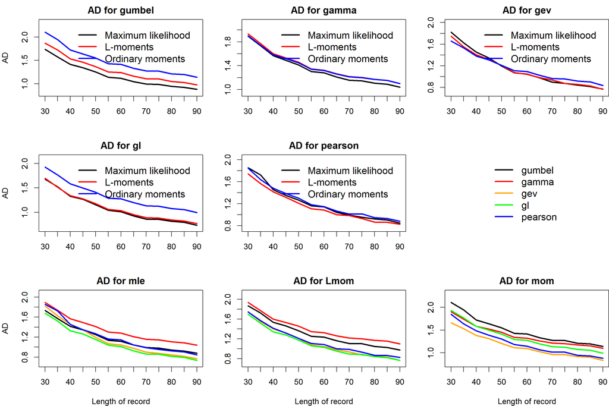